# First-Year Blocking Project Milestone 3

Adiya Abdilkhay, Dasha Metropolitansky, Alistair Gluck, Christopher Milne, April Chen, Niel Schrage, Ilkin Bayramli, Stephanie Yao

04/05/2019

# Data Collection Overview

Data collection and cleaning has taken up the bulk of our time that we have devoted to the project, and we are still continuously cleaning the data and trying to get it into a form from which we can create our Shiny app and various graphics.

Data was collected first by using the Harvard Facebook website that contains everyone in the Class of 2022 and their names, this would eventually be updated with everyone’s houses, which would be of great help and eliminate the need for a second survey.

The main data collection was conducted via survey that we sent to each dorm’s mailing list and tabled at annenberg to publicize. The survey included questions of current living situation, legacy, international, and financial aid status. We gathered the athlete data from the various rosters on the Harvard Athletics website.

The next step is to clean the data to enable us to use every entry in calculations (this is ongoing). We potentially plan to create functions to help us.

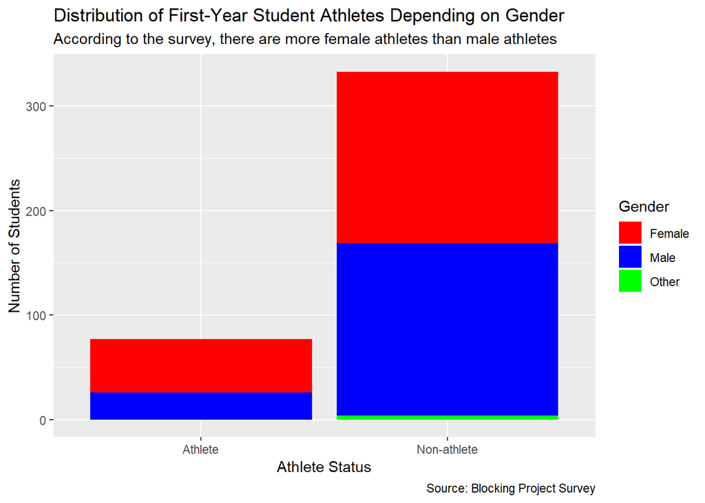